# 02_Models

2025-03-15

```r
library(dplyr)
library(caret)
library(keras)
library(ggplot2)
library(recipes)
library(reshape2)
library(ggridges)
library(gridExtra)
library(patchwork)
library(tidymodels)
library(FactoMineR)
```

## Load

Loading Pre-processed data provided

```r
## load
load(here::here("Data", "ProcessedData", "processed_AnalysisData.Rdata"))
```

```r
processed_data
```

```
## # A tibble: 14,575 × 484
##    fishNum dateSample dateTimeSample      dateProcessed species   spCode
##    <chr>   <date>     <dttm>              <date>        <chr>      <dbl>
##  1 LT001   2022-07-21 2022-07-21 16:56:00 2022-07-27    lakeTrout     81
##  2 LT001   2022-07-21 2022-07-21 16:56:00 2022-07-27    lakeTrout     81
##  3 LT001   2022-07-21 2022-07-21 16:56:00 2022-07-27    lakeTrout     81
##  4 LT001   2022-07-21 2022-07-21 16:56:00 2022-07-27    lakeTrout     81
##  5 LT001   2022-07-21 2022-07-21 16:56:00 2022-07-27    lakeTrout     81
##  6 LT001   2022-07-21 2022-07-21 16:56:00 2022-07-27    lakeTrout     81
##  7 LT001   2022-07-21 2022-07-21 16:56:00 2022-07-27    lakeTrout     81
##  8 LT001   2022-07-21 2022-07-21 16:56:00 2022-07-27    lakeTrout     81
##  9 LT001   2022-07-21 2022-07-21 16:56:00 2022-07-27    lakeTrout     81
## 10 LT001   2022-07-21 2022-07-21 16:56:00 2022-07-27    lakeTrout     81
## # ℹ 14,565 more rows
## # ℹ 478 more variables: totalLength <dbl>, forkLength <dbl>, weight <dbl>,
## #   girth <dbl>, dorsoLatHeight <dbl>, clipTag <chr>, sex <chr>, mat <dbl>,
## #   airbladderTotalLength <dbl>, airBladderWidth <dbl>, airbladderWeight <dbl>,
## #   airBladderWeightCond <dbl>, agingStructure <chr>, tissueSample <chr>,
## #   Region_name <chr>, FishTrack <chr>, MaxTSdiff <dbl>, Ping_time <chr>,
## #   deltaRange <dbl>, deltaMinAng <dbl>, deltaMajAng <dbl>, …
```

```r
## variable names in data
names(processed_data)
```

```
##   [1] "fishNum"                       "dateSample"
##   [3] "dateTimeSample"                "dateProcessed"
##   [5] "species"                       "spCode"
##   [7] "totalLength"                   "forkLength"
##   [9] "weight"                        "girth"
##  [11] "dorsoLatHeight"                "clipTag"
##  [13] "sex"                           "mat"
##  [15] "airbladderTotalLength"         "airBladderWidth"
##  [17] "airbladderWeight"              "airBladderWeightCond"
##  [19] "agingStructure"                "tissueSample"
##  [21] "Region_name"                   "FishTrack"
##  [23] "MaxTSdiff"                     "Ping_time"
##  [25] "deltaRange"                    "deltaMinAng"
##  [27] "deltaMajAng"                   "aspectAngle"
##  [29] "Target_range"                  "Angle_minor_axis"
```

[output cut: 227 more lines]

## Data Preparation

1. We only focuses on the target strength data from the fish species, thus, we first only create a dataframe that contains the frequency response across all pings for fish.

```r
frequency_data <- (
  processed_data
  |> dplyr::select(c(1, 5, 59:481))
)
frequency_data |> head()
```

```
## # A tibble: 6 × 425
##   fishNum species     F45 F45.5   F46 F46.5   F47 F47.5   F48 F48.5   F49 F49.5
##   <chr>   <chr>     <dbl> <dbl> <dbl> <dbl> <dbl> <dbl> <dbl> <dbl> <dbl> <dbl>
## 1 LT001   lakeTrout -48.9 -47.5 -45.9 -44.2 -43.0 -41.7 -40.6 -39.6 -38.6 -37.7
## 2 LT001   lakeTrout -47.4 -47.6 -47.1 -45.5 -43.6 -41.6 -40.1 -39.0 -38.0 -37.2
## 3 LT001   lakeTrout -47.9 -49.3 -49.3 -47.2 -44.9 -42.7 -41.0 -39.5 -38.3 -37.2
## 4 LT001   lakeTrout -44.3 -45.7 -47.6 -48.8 -48.6 -46.7 -44.7 -42.9 -41.5 -40.3
## 5 LT001   lakeTrout -41.4 -42.3 -43.6 -44.7 -45.9 -46.6 -46.9 -46.7 -46.0 -45.1
## 6 LT001   lakeTrout -33.8 -33.7 -33.7 -33.5 -33.7 -33.8 -34.0 -34.1 -34.2 -34.2
## # ℹ 413 more variables: F50 <dbl>, F50.5 <dbl>, F51 <dbl>, F51.5 <dbl>,
## #   F52 <dbl>, F52.5 <dbl>, F53 <dbl>, F53.5 <dbl>, F54 <dbl>, F54.5 <dbl>,
## #   F55 <dbl>, F55.5 <dbl>, F56 <dbl>, F56.5 <dbl>, F57 <dbl>, F57.5 <dbl>,
## #   F58 <dbl>, F58.5 <dbl>, F59 <dbl>, F59.5 <dbl>, F60 <dbl>, F60.5 <dbl>,
## #   F61 <dbl>, F61.5 <dbl>, F62 <dbl>, F62.5 <dbl>, F63 <dbl>, F63.5 <dbl>,
## #   F64 <dbl>, F64.5 <dbl>, F65 <dbl>, F65.5 <dbl>, F66 <dbl>, F66.5 <dbl>,
## #   F67 <dbl>, F67.5 <dbl>, F68 <dbl>, F68.5 <dbl>, F69 <dbl>, F69.5 <dbl>, …
```

2. We next remove the fish `LT008` because it is missing all high frequency data from `F173` to `F258.5` for all pings, where results in a total of 31476 `NA` value and fill in values is not meaningful at all.

```r
frequency_data <- (
  frequency_data
  |> filter(fishNum != "LT008")
)
unique(frequency_data$fishNum)
```

```
##  [1] "LT001"  "LT002"  "LT003"  "LT004"  "LT005"  "LT006"  "LT007"  "LT009"
##  [9] "LT010"  "LT011"  "LT012"  "LT013"  "LT014"  "LT015"  "LT016"  "LT017"
## [17] "LT018"  "LT019"  "LT020"  "LT021"  "LWF001" "LWF002" "LWF003" "LWF007"
## [25] "LWF009" "LWF010" "LWF011" "LWF012" "LWF013" "LWF014" "LWF015" "SMB001"
## [33] "SMB002" "SMB004" "SMB005" "SMB006" "SMB007" "SMB008" "SMB009" "SMB010"
## [41] "SMB011" "SMB012" "SMB013"
```

3. We then remove the data columns `F90` to `F170` because they did not record in the original data, where all columns are `NA` values for all ping data and all fish.

```r
frequency_data <- frequency_data |> dplyr::select(-c(93:253))
```

4. Prepare class levels and number of classes in the data for model development use

```r
all_species <- unique(frequency_data$species)
num_classes <- length(all_species)
```

### Train and Test set by fishNum

We then want to create a train and test set by fish ID. We want to randomly choose 70% Train set and 30% Test set.

```r
set.seed(2453)

## unique fish id
unique_fishNum <- frequency_data |> distinct(fishNum, species)

## create stratified split
train_indices <- createDataPartition(
  unique_fishNum$species,
  p = 0.7,
  list = FALSE
)

## create train/test fish ID set
train_fish <- unique_fishNum[train_indices, ]
test_fish <- unique_fishNum[-train_indices, ]

## split into train/test set
train_data <- frequency_data |> filter(fishNum %in% train_fish$fishNum)
test_data <- frequency_data |> filter(fishNum %in% test_fish$fishNum)
dim(train_data)
```

```
## [1] 10328   264
```

```r
dim(test_data)
```

```
## [1] 4064  264
```

### Prepare Data for different models

We want to create a classification system that using the following models:

1. Logistics regression (with PCA)
2. Random Forest (Raw data)
3. Deep Neural Network (Raw data)
4. LSTM (Raw Sequence data)
5. LSTM with attention layer (Raw Sequence data)
6. CNN (Raw Sequence data)

We need to prepare three type od data.

```r
## standardized data
preProc <- preProcess(train_data, method = c("center", "scale"))
train_std_data <- predict(preProc, train_data)
test_std_data <- predict(preProc, test_data)

## raw data
train_raw_data <- train_data
test_raw_data <- test_data

## create sequence data
create_sequences_data <- function(data) {

  ## group by fish
  grouped_data <- (
    train_data
    |> group_by(fishNum)
    |> mutate(n_pings = n())
    |> ungroup()
    |> group_split(fishNum)
  )

  # Extract metadata
  labels <- map_chr(grouped_data, ~ unique(.x$species))
  # labels <- unique(grouped_data$species)
  fishNums <- map_chr(grouped_data, ~ unique(.x$fishNum))
  # fishNums <- unique(grouped_data$fishNum)

  ## convert to list of matrices
  sequences <- (
    grouped_data
    |> map(~ {
      freq_cols <- (
        .x
        |> dplyr::select(-c(fishNum, species))
        |> dplyr::select(where(is.numeric))
      )
      as.matrix(freq_cols)
    })
  )

  return(list(
    fishNum = fishNums,
    species = labels,
    sequences = sequences
  ))
}
train_seq_data <- create_sequences_data(train_std_data)
test_seq_data <- create_sequences_data(test_std_data)
```

## Models

### Logistics Regression

```r
###############################################################################
# PCA-Logistic Regression Pipeline with 90% Variance Retention
# ------------------------------------------------------------
# This script:
# 1. Applies PCA to standardized frequency data
# 2. Retains components explaining ≥90% cumulative variance
# 3. Trains logistic regression on reduced dimensions
# 4. Evaluates performance on test set
###############################################################################

## fish level standard data
train_std_fish_level_data <- (
  train_std_data
  |> group_by(fishNum, species)
  |> summarise(across(starts_with("F"), mean))
  |> ungroup()
)
test_std_fish_level_data <- (
  test_std_data
  |> group_by(fishNum, species)
  |> summarise(across(starts_with("F"), mean))
  |> ungroup()
)
## Apply PCA
## define recipe
pca_recipe <- (
  recipe(species ~ ., data = train_std_fish_level_data)
  ## keeping fishNum but exclude from analysis
  |> update_role(fishNum, new_role = "ID")
  ## want PCs at least have 90% variance explained
  |> step_pca(
    all_numeric_predictors(),
    threshold = 0.9,
    options = list(center = FALSE, scale. = FALSE)
  )
)

## define model
## using multinomial regression
multinom_model <- (
  multinom_reg()
  |> set_engine("nnet")
  |> set_mode("classification")
)

## assembly workflow
pca_multinom_wf <- (
  workflow()
  |> add_recipe(pca_recipe)
  |> add_model(multinom_model)
)

## train model
fit_pca_multinom <- (
  pca_multinom_wf
  |> fit(data = train_std_fish_level_data)
)

## Variance Explanation Analysis
## extract PCA details
pca_multinom_res <- (
  extract_preprocessor(fit_pca_multinom)
  |> prep()
)

## extract variance explained metrics
pca_multinom_model <- pca_multinom_res$steps[[1]]$res
pca_multinom_variance <- pca_multinom_model$sdev^2
pca_multinom_variance_cum_variance <- cumsum(pca_multinom_variance / sum(pca_multinom_variance))

pca_multinom_variance_tbl <- (
  tibble(
    component = paste0("PC", seq_along(pca_multinom_variance_cum_variance)),
    cumulative_variance = pca_multinom_variance_cum_variance
  )
  |> filter(
    cumulative_variance <= 0.9 | row_number() == which.max(cumulative_variance >= 0.9)
  )
)

# print
cat("\nPCA Variance Explanation:\n")
```

```
##
## PCA Variance Explanation:
```

```r
print(pca_multinom_variance_tbl)
```

```
## # A tibble: 2 × 2
##   component cumulative_variance
##   <chr>                   <dbl>
## 1 PC1                     0.889
## 2 PC2                     0.960
```

```r
cat("Number of components retained:", nrow(pca_multinom_variance_tbl), "\n")
```

```
## Number of components retained: 2
```

```r
## Model Predictions
## generate test results
predict_pca_multinom <- (
  test_std_fish_level_data
  |> bind_cols(
    predict(fit_pca_multinom, new_data = test_std_fish_level_data), ## compute class predictions
    predict(fit_pca_multinom, new_data = test_std_fish_level_data, type = "prob") ## compute probabilities
  )
  |> mutate(species = factor(species))
)

## performance metrics
model_metrics <- metric_set(accuracy, sensitivity, specificity)
performance_pca_multinom <- (
  predict_pca_multinom
  |> model_metrics(
    truth = species,
    estimate = .pred_class
  )
)

# Compute multiclass roc_auc separately with all probability columns
pca_multinom_roc_auc_res <- (
  predict_pca_multinom
  |> roc_auc(
    truth = species,
    c(.pred_lakeTrout, .pred_lakeWhitefish, .pred_smallmouthBass),
    estimator = "hand_till"
  )
)


## Model Performance
## confusion matrix
cat("\nConfusion Matrix:\n")
```

```
##
## Confusion Matrix:
```

```r
print(conf_mat(predict_pca_multinom, truth = species, estimate = .pred_class))
```

```
##                 Truth
## Prediction       lakeTrout lakeWhitefish smallmouthBass
##   lakeTrout              5             2              2
##   lakeWhitefish          0             1              0
##   smallmouthBass         1             0              1
```

```r
cat("\nModel Performance Metrics:\n")
```

```
##
## Model Performance Metrics:
```

```r
print(performance_pca_multinom)
```

```
## # A tibble: 3 × 3
##   .metric     .estimator .estimate
##   <chr>       <chr>          <dbl>
## 1 accuracy    multiclass     0.583
## 2 sensitivity macro          0.5
## 3 specificity macro          0.741
```

```r
## PCA laoding contributions
pca_multinom_loadings <- pca_multinom_model$rotation[, "PC1"]
pca_multinom_loadings_contributions_tbl <- (
  tibble(
    Frequency = names(pca_multinom_loadings),
    Loading = pca_multinom_loadings,
    Absolute_Loading = abs(pca_multinom_loadings)
  )
  |> arrange(desc(Absolute_Loading))
)

head(pca_multinom_loadings_contributions_tbl, 20)
```

```
## # A tibble: 20 × 3
##    Frequency Loading Absolute_Loading
##    <chr>       <dbl>            <dbl>
##  1 F177      -0.0694           0.0694
##  2 F177.5    -0.0690           0.0690
##  3 F178      -0.0690           0.0690
##  4 F178.5    -0.0687           0.0687
##  5 F186      -0.0686           0.0686
##  6 F179      -0.0686           0.0686
##  7 F185.5    -0.0686           0.0686
##  8 F188.5    -0.0685           0.0685
##  9 F188      -0.0685           0.0685
## 10 F179.5    -0.0685           0.0685
## 11 F175.5    -0.0684           0.0684
## 12 F87.5     -0.0684           0.0684
## 13 F176.5    -0.0682           0.0682
## 14 F86.5     -0.0682           0.0682
## 15 F186.5    -0.0681           0.0681
## 16 F189      -0.0681           0.0681
## 17 F187.5    -0.0680           0.0680
## 18 F87       -0.0680           0.0680
## 19 F86       -0.0679           0.0679
## 20 F176      -0.0679           0.0679
```

### Random Forest

```r
set.seed(2453)

## Random Forest
## define recipe
rf_recipe <- (
  recipe(species ~ ., data = train_raw_data)
  |> update_role(fishNum, new_role = "ID")
)

## define random forest model
rf_model <- (
  rand_forest(
    trees = tune(),
    mtry = tune(),
    min_n = tune()
  )
  |> set_engine("ranger", importance = "impurity")
  |> set_mode("classification")
)

## workflow assemble
rf_wf <- (
  workflow()
  |> add_recipe(rf_recipe)
  |> add_model(rf_model)
)

## tune hyperparameters
rf_folds <- vfold_cv(train_raw_data, v = 5)
rf_grid <- grid_regular(
  trees(range = c(100, 500)), # 300  600  900 1200 1500
  mtry(range = c(10, 50)),    # 10  32  55  77 100
  min_n(range = c(1, 20)),     # 1  5 10 15 20
  levels = 5
)

## took 6 hours to tune
# rf_tuned_model <- (
#   rf_wf
#   |> tune_grid(
#     resamples = rf_folds,
#     grid = rf_grid,
#     metrics = metric_set(accuracy)
#     )
#   )
# ## save to RDS
# save(rf_tuned_model, file = here::here("Output", "Data", "02_RF_Tuned_Models.rds"))
```

```r
## load tuned models
load(here::here("Output", "Data", "02_RF_Tuned_Models.rds"))
# Select the best hyperparameters
rf_best_parameters <- rf_tuned_model |> tune::select_best(metric = "accuracy")
rf_best_parameters
```

```
## # A tibble: 1 × 4
##    mtry trees min_n .config
##   <int> <int> <int> <chr>
## 1    20   400     5 Preprocessor1_Model034
```

```r
## finalize the best model for prediction
fit_rf_best <- (
  rf_wf
  |> finalize_workflow(rf_best_parameters)
  |> fit(train_raw_data)
)

## predict on the test data
predict_rf_best <- (
  test_raw_data
  |> bind_cols(
    predict(fit_rf_best, new_data = test_raw_data),
    predict(fit_rf_best, new_data = test_raw_data, type = "prob")
    )
  |> mutate(species = factor(species))
)

## performance metrics
rf_metric <- metric_set(accuracy)
performance_rf_best <- (
  predict_rf_best
  |> model_metrics(
    truth = species,
    estimate = .pred_class
  )
)


## Model Performance

## create tibble to store predictions for model performance comparison
rf_predictions <- tibble(
  fishNum = test_std_data$fishNum,
  species = test_std_data$species,
  pred_class = predict_rf_best$.pred_class
)

## count majority predictions on ping data for a single fish
## to determine the dnn prediction for this fish
rf_fish_level_pred <- (
  rf_predictions
  |> group_by(fishNum)
  |> summarise(
    pred_class = names(which.max(table(pred_class))),
    species = first(species)
  )
  |> mutate(
    pred_class = factor(pred_class, levels = all_species),
    species = factor(species, levels = all_species)
  )
)
rf_fish_level_pred
```

```
## # A tibble: 12 × 3
##    fishNum pred_class    species
##    <chr>   <fct>         <fct>
##  1 LT001   lakeTrout     lakeTrout
##  2 LT002   lakeTrout     lakeTrout
##  3 LT005   lakeTrout     lakeTrout
##  4 LT009   lakeTrout     lakeTrout
##  5 LT012   lakeTrout     lakeTrout
##  6 LT020   lakeTrout     lakeTrout
##  7 LWF012  lakeWhitefish lakeWhitefish
##  8 LWF013  lakeWhitefish lakeWhitefish
##  9 LWF015  lakeWhitefish lakeWhitefish
## 10 SMB002  lakeTrout     smallmouthBass
## 11 SMB005  lakeTrout     smallmouthBass
## 12 SMB006  lakeTrout     smallmouthBass
```

```r
## compute and show ping predictions counts
rf_predictions_count <- (
  rf_predictions
  |> group_by(fishNum, species, pred_class)
  |> summarise(n = n(), .groups = "drop")
  |> pivot_wider(
    names_from = pred_class,
    values_from = n,
    values_fill = 0,
    names_prefix = "Pred_"
  )
)
rf_predictions_count$Pred_class <- rf_fish_level_pred$pred_class
rf_predictions_count
```

```
## # A tibble: 12 × 6
##    fishNum species        Pred_lakeTrout Pred_lakeWhitefish Pred_smallmouthBass
##    <chr>   <chr>                   <int>              <int>               <int>
##  1 LT001   lakeTrout                  51                 14                   1
##  2 LT002   lakeTrout                 368                347                  35
##  3 LT005   lakeTrout                 278                 24                   7
##  4 LT009   lakeTrout                 276                 31                  13
##  5 LT012   lakeTrout                 159                  7                   4
##  6 LT020   lakeTrout                 197                  8                   8
##  7 LWF012  lakeWhitefish              80                199                   4
##  8 LWF013  lakeWhitefish             164                258                   0
##  9 LWF015  lakeWhitefish              44                 52                   0
## 10 SMB002  smallmouthBass            158                123                  35
## 11 SMB005  smallmouthBass             29                 13                   6
## 12 SMB006  smallmouthBass            982                 34                  55
## # ℹ 1 more variable: Pred_class <fct>
```

```r
# Compute accuracy
rf_accuracy <- (
  rf_fish_level_pred
  |> accuracy(truth = species, estimate = pred_class)
)

## confusion matrix
rf_conf_mat <- (
  rf_fish_level_pred
  |> conf_mat(truth = species, estimate = pred_class)
)

## Output
## confusion matrix
cat("\nConfusion Matrix:\n")
```

```
##
## Confusion Matrix:
```

```r
print(rf_conf_mat)
```

```
##                 Truth
## Prediction       lakeTrout lakeWhitefish smallmouthBass
##   lakeTrout              6             0              3
##   lakeWhitefish          0             3              0
##   smallmouthBass         0             0              0
```

```r
cat("\nModel Performance Metrics:\n")
```

```
##
## Model Performance Metrics:
```

```r
print(rf_accuracy)
```

```
## # A tibble: 1 × 3
##   .metric  .estimator .estimate
##   <chr>    <chr>          <dbl>
## 1 accuracy multiclass      0.75
```

### Deep Nerual Network

```r
#### some useful note
#### install.package("keras")
#### install.package("tensorflow)"
#### library(tensorflow)
#### install_tensorflow(version = "2.13.1")
#### for model to run properly

## Nerual Networks
## prepare data
train_dnn_data <- (
  train_std_data
  |> mutate(species = factor(species))
  |> select(-fishNum)
)

test_dnn_data <- (
  test_std_data
  |> mutate(species = factor(species))
  |> select(-fishNum)
)

## separate features and lables

## train
train_dnn_x <- (
  train_dnn_data
  |> dplyr::select(starts_with(("F")))
  |> as.matrix()
)

train_dnn_y <- (
  train_dnn_data
  |> pull(species)
  |> as.numeric() - 1
)

## test
test_dnn_x <- (
  test_dnn_data
  |> dplyr::select(starts_with(("F")))
  |> as.matrix()
)

test_dnn_y <- (
  test_dnn_data
  |> pull(species)
  |> as.numeric() - 1
)

## one-hot encode labels
train_dnn_y <- to_categorical(train_dnn_y, num_classes = num_classes)
test_dnn_y <- to_categorical(test_dnn_y, num_classes = num_classes)

## DNN model
## define model with 3 hidden layers
dnn_model <- (
  keras_model_sequential()
  |> layer_dense(units = 128, activation = 'relu', input_shape = ncol(train_dnn_x))
  |> layer_dropout(rate = 0.3)
  |> layer_dense(units = 64, activation = 'relu')
  |> layer_dropout(rate = 0.3)
  |> layer_dense(units = 32, activation = "relu")
  |> layer_dense(units = num_classes, activation = "softmax")
)

## compile the model
(
  dnn_model
  |> compile(
    loss = "categorical_crossentropy",
    optimizer = optimizer_adam(learning_rate = 0.001),
    metrics = "accuracy"
  )
)
```

```
## Model: "sequential"
## ________________________________________________________________________________
##  Layer (type)                       Output Shape                    Param #
## ================================================================================
##  dense_3 (Dense)                    (None, 128)                     33664
##  dropout_1 (Dropout)                (None, 128)                     0
##  dense_2 (Dense)                    (None, 64)                      8256
##  dropout (Dropout)                  (None, 64)                      0
##  dense_1 (Dense)                    (None, 32)                      2080
##  dense (Dense)                      (None, 3)                       99
## ================================================================================
## Total params: 44099 (172.26 KB)
## Trainable params: 44099 (172.26 KB)
## Non-trainable params: 0 (0.00 Byte)
## ________________________________________________________________________________
```

```r
## create validation sets for model development
dnn_grouped_data <- (
  train_std_data
  |> mutate(group = fishNum)
  # |> group_by(group)
  # |> nest()
)
## create folds
dnn_folds <- group_initial_split(dnn_grouped_data, group = "fishNum", prop = 0.8)
train_dnn_folds <- (
  training(dnn_folds)
)
val_dnn_folds <- (
  testing(dnn_folds)
)

val_dnn_x <- (
  val_dnn_folds
  |> select(-fishNum)
  |> select(starts_with("F"))
  |> as.matrix()
)
val_dnn_y <- (
  val_dnn_folds
  |> mutate(species = factor(species))
  |> pull(species)
  |> as.numeric() - 1
)
val_dnn_y <- to_categorical(val_dnn_y, num_classes = num_classes)

## train model
dnn_history <- (
  dnn_model
  |> fit(
    x = train_dnn_x,
    y = train_dnn_y,
    epochs = 100,
    batch_size = 32,
    validation_data = list(val_dnn_x, val_dnn_y),
    verbose = 1
  )
)
## evaluate model
(
  dnn_model
  |> evaluate(test_dnn_x, test_dnn_y)
)
```

```
## 127/127 - 0s - loss: 1.7202 - accuracy: 0.4673 - 53ms/epoch - 416us/step
```

```
##      loss  accuracy
## 1.7202024 0.4672736
```

```r
## predict
predict_dnn <- (
  dnn_model
  |> predict(test_dnn_x)
  |> k_argmax()
)
```

```
## 127/127 - 0s - 77ms/epoch - 608us/step
```

```r
predict_dnn
```

```
## tf.Tensor([0 0 0 ... 2 0 0], shape=(4064), dtype=int64)
```

```r
## Convert history to a tibble
dnn_history_df <- as.data.frame(dnn_history$metrics)
dnn_history_df$epoch <- seq(from = 1, to = 100)
dnn_history_df
```

```
##          loss  accuracy  val_loss val_accuracy epoch
## 1   0.9207851 0.5680674 0.6162120    0.8333333     1
## 2   0.8166763 0.6250968 0.6426367    0.7904192     2
## 3   0.7727738 0.6528854 0.6475667    0.8103793     3
## 4   0.7367719 0.6711851 0.6216758    0.7934132     4
## 5   0.6999449 0.6953912 0.6733780    0.7544910     5
## 6   0.6701319 0.7108830 0.6517537    0.7539920     6
## 7   0.6421860 0.7205654 0.6062240    0.7664671     7
## 8   0.6255079 0.7355732 0.5985578    0.7559880     8
## 9   0.6051252 0.7441906 0.5136617    0.8567864     9
## 10  0.5831673 0.7570682 0.5277605    0.7904192    10
## 11  0.5712864 0.7591015 0.4798227    0.8408183    11
## 12  0.5533430 0.7712045 0.4785988    0.8318363    12
## 13  0.5412404 0.7723664 0.4514890    0.8577845    13
## 14  0.5322946 0.7751743 0.5711799    0.7609780    14
```

[output cut: 86 more lines]

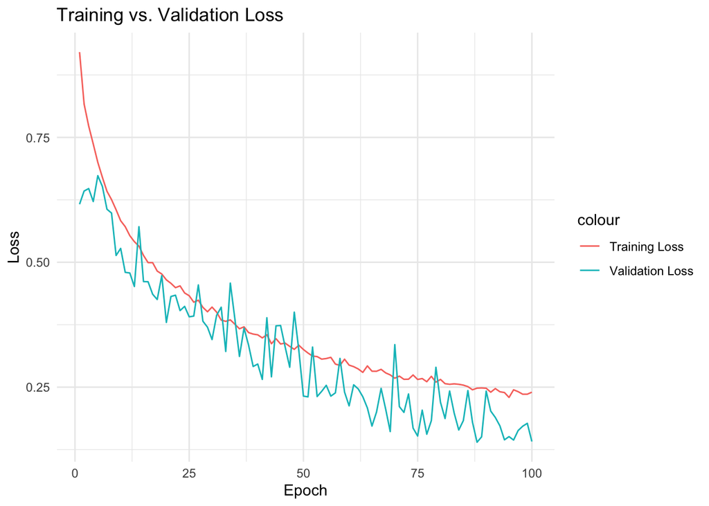

```r
## Plot loss
ggplot(dnn_history_df, aes(x = epoch)) +
  geom_line(aes(y = loss, color = "Training Loss")) +
  geom_line(aes(y = val_loss, color = "Validation Loss")) +
  labs(title = "Training vs. Validation Loss", y = "Loss", x = "Epoch") +
  theme_minimal()
```

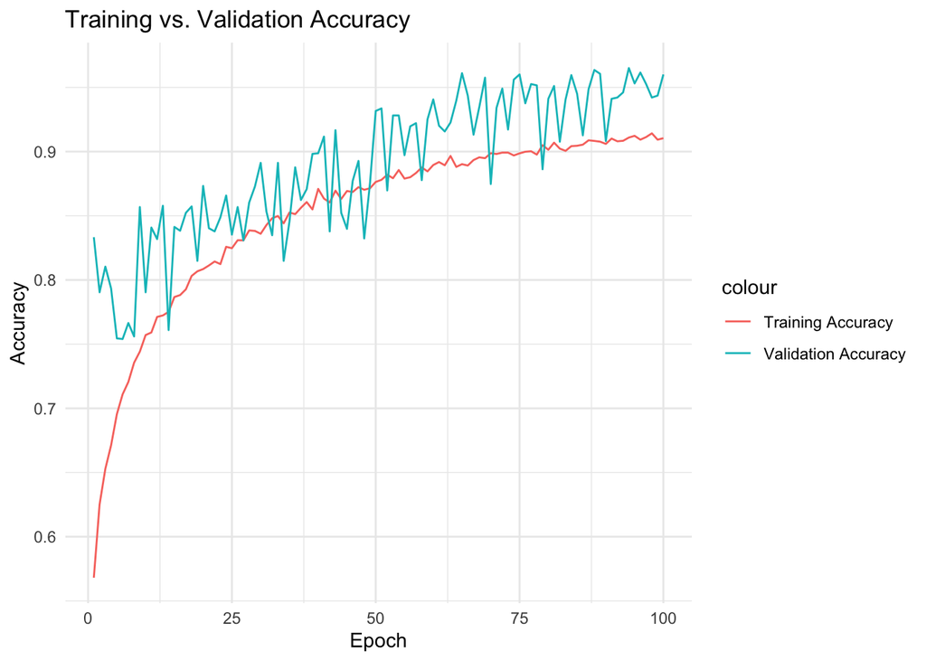

```r
## Plot accuracy
ggplot(dnn_history_df, aes(x = epoch)) +
  geom_line(aes(y = accuracy, color = "Training Accuracy")) +
  geom_line(aes(y = val_accuracy, color = "Validation Accuracy")) +
  labs(title = "Training vs. Validation Accuracy", y = "Accuracy", x = "Epoch") +
  theme_minimal()
```

```r
## Model Performance
## convert prediction to numeric values
dnn_pred_classes <- as.numeric(predict_dnn$numpy())

## create tibble to store predictions for model performance comparison
dnn_predictions <- tibble(
  fishNum = test_std_data$fishNum,
  species = test_std_data$species,
  pred_class = dnn_pred_classes
)

## count majority predictions on ping data for a single fish
## to determine the dnn prediction for this fish
dnn_fish_level_pred <- (
  dnn_predictions
  |> group_by(fishNum)
  |> summarise(
    pred_class = as.integer(names(which.max(table(pred_class)))),
    species = first(species)
  )
  |> ungroup()
  |> mutate(
    pred_class = case_when(
      pred_class == 0 ~ "lakeTrout",
      pred_class == 1 ~ "lakeWhitefish",
      pred_class == 2 ~ "smallmouthBass",
      TRUE ~ NA_character_ ## set default case for any other values
    ),
    species = factor(species, levels = all_species),
    pred_class = factor(pred_class, levels = all_species)
  )
)

## compute and show ping predictions counts
dnn_predictions_count <- (
  dnn_predictions
  |> group_by(fishNum, species, pred_class)
  |> summarise(n = n(), .groups = "drop")
  |> pivot_wider(
    names_from = pred_class,
    values_from = n,
    values_fill = 0,
    names_prefix = "Pred_"
  )
)
dnn_predictions_count$Pred_class <- dnn_fish_level_pred$pred_class

dnn_predictions_count
```

```
## # A tibble: 12 × 6
##    fishNum species        Pred_0 Pred_1 Pred_2 Pred_class
##    <chr>   <chr>           <int>  <int>  <int> <fct>
##  1 LT001   lakeTrout          37     20      9 lakeTrout
##  2 LT002   lakeTrout         148    513     89 lakeWhitefish
##  3 LT005   lakeTrout         193     71     45 lakeTrout
##  4 LT009   lakeTrout         212     46     62 lakeTrout
##  5 LT012   lakeTrout         126     13     31 lakeTrout
##  6 LT020   lakeTrout         169     11     33 lakeTrout
##  7 LWF012  lakeWhitefish      28    241     14 lakeWhitefish
##  8 LWF013  lakeWhitefish      25    388      9 lakeWhitefish
##  9 LWF015  lakeWhitefish      28     52     16 lakeWhitefish
## 10 SMB002  smallmouthBass     90    162     64 lakeWhitefish
## 11 SMB005  smallmouthBass     21     15     12 lakeTrout
## 12 SMB006  smallmouthBass    759     55    257 lakeTrout
```

```r
# Compute accuracy
dnn_accuracy <- (
  dnn_fish_level_pred
  |> accuracy(truth = species, estimate = pred_class)
)

## confusion matrix
dnn_conf_mat <- (
  dnn_fish_level_pred
  |> conf_mat(truth = species, estimate = pred_class)
)

## Output
## confusion matrix
cat("\nConfusion Matrix:\n")
```

```
##
## Confusion Matrix:
```

```r
print(dnn_conf_mat)
```

```
##                 Truth
## Prediction       lakeTrout lakeWhitefish smallmouthBass
##   lakeTrout              5             0              2
##   lakeWhitefish          1             3              1
##   smallmouthBass         0             0              0
```

```r
cat("\nModel Performance Metrics:\n")
```

```
##
## Model Performance Metrics:
```

```r
print(dnn_accuracy)
```

```
## # A tibble: 1 × 3
##   .metric  .estimator .estimate
##   <chr>    <chr>          <dbl>
## 1 accuracy multiclass     0.667
```